# MovieLens Report

Spencer Fisher

12/20/2020

## Introduction

I created a machine learning model that predicts the rating that an individual user will give a certain movie. This is useful because models like this can be used to recommend movies to a user that they would like to watch based on the rating of previous movies that they have watched. Better recommendations can lead to more viewing time by users and higher customer satisfaction. Both of these lead to higher revenue.

The dataset that was used to create my model is the movieLens dataset. Each row in the dataset represents a rating that was submitted. The dataset contains six columns, userId, movieId, rating, timestamp, title, and genres. The userId is a column of unique numbers that each individual user has, to represent who submitted the rating. The movieId is a column of unique numbers that represent what movie the rating was for. The rating column is a number 0-5 which represents how many stars were given as the rating. The timestamp column is a timestamp of when the rating was given. The title is a column that represents the title of the movie that was rated. Finally, the genres column represents what genre the movie is. I used different subsets of this dataset to train my model.

```r
head(edx)
```

```
##   userId movieId rating timestamp                         title
## 1      1     122      5 838985046              Boomerang (1992)
## 2      1     185      5 838983525               Net, The (1995)
## 4      1     292      5 838983421               Outbreak (1995)
## 5      1     316      5 838983392               Stargate (1994)
## 6      1     329      5 838983392 Star Trek: Generations (1994)
## 7      1     355      5 838984474       Flintstones, The (1994)
##                          genres
## 1                Comedy|Romance
## 2         Action|Crime|Thriller
## 4  Action|Drama|Sci-Fi|Thriller
## 5       Action|Adventure|Sci-Fi
## 6 Action|Adventure|Drama|Sci-Fi
## 7       Children|Comedy|Fantasy
```

## Method/Analysis

To make my model, before I could start, I had to first both download and understand the data. The edx set is used for training, while the validation set is used for the very final test of the model. The edx dataset has 9,000,055 rows each representing a different rating of a movie by a unique user.

```r
dim(edx)
```

```
## [1] 9000055       6
```

Because the dataset is so large, training models using the data would take far too long, so I used the createDataPartition function to further split the edx set into test and training sets. The training set is 90% of the edx set and the test set is 10%.

```r
set.seed(1)
sample.kind="Rounding"
test_index <- createDataPartition(y = edx$rating, times = 1, p = 0.1, list = FALSE)
train_set <- edx[-test_index,]
test_set <- edx[test_index,]
```

Next, I had to do some data cleaning. The first thing that I did was make sure that the userIds and movieIds that are in the test set are also in the training set because otherwise we would have no information about them to use to predict.

```r
test_set <- test_set %>%
  semi_join(train_set, by = "movieId") %>%
  semi_join(train_set, by = "userId")
```

Second, I had to make sure that there were no NAs in the dataset. An NA is an observation that is blank. This would throw off certain models, so I checked the number of NAs that were in each column, and since this was zero for every column, I didn’t have to do anything else regarding NAs.

```r
sapply(edx,function(x) sum(is.na(x)))
```

```
##    userId   movieId    rating timestamp     title    genres
##         0         0         0         0         0         0
```

The next step was understanding the data so that I could have a better understanding of where to start. I started by looking for distributions of different columns. When plotting the average rating for each movie I noticed that there is a lot of variation of the average depending on the movie. This makes sense because some movies are better than others.

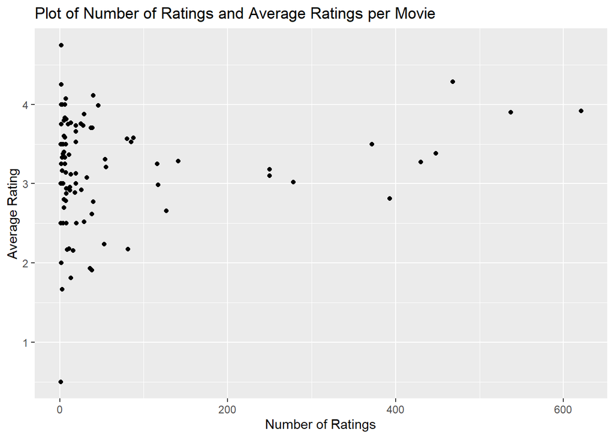

I also decided to do this for users, and similarly, there is a lot of variation showing that different users rate movies more or less strictly.

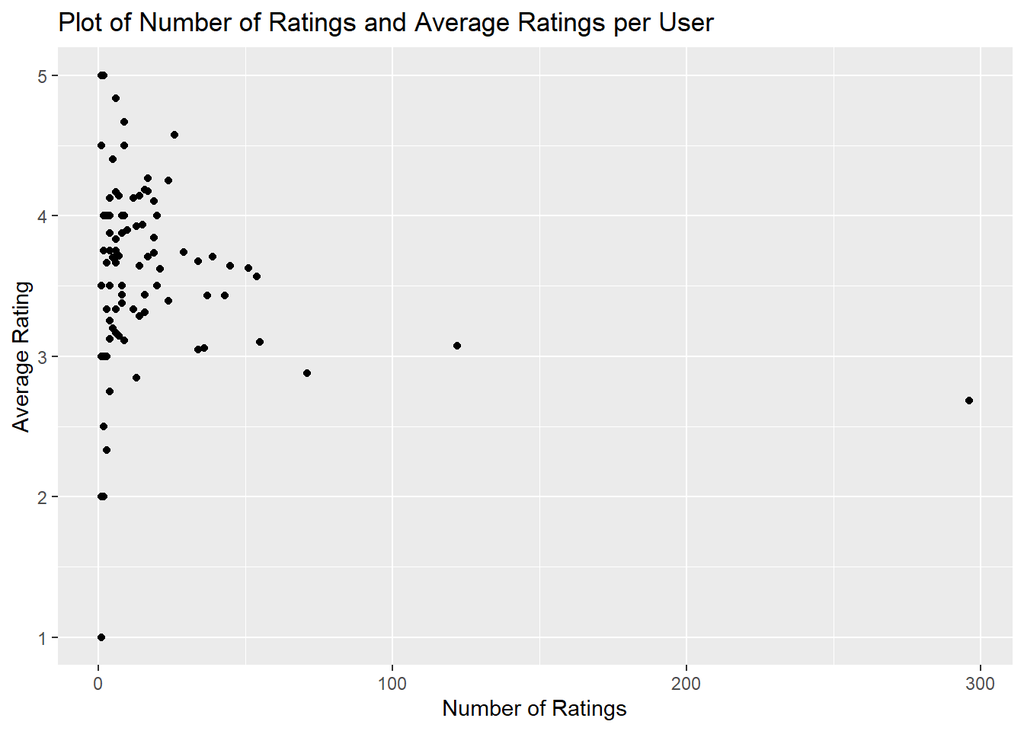

Throughout the making of this model, I will be using the root-mean-squared-error (RMSE) as a measure of the accuracy of the different models. The formula for the RMSE is:

```r
RMSE <- function(actual, pred){
  sqrt(mean((actual-pred)^2))
}
```

The formula gets the average distance of the model’s prediction and the actual value, then the square root and square parts of the equation are to get the absolute value of the distance. In this case, an RMSE of 1.0 represents that on average, your models’ predictions will be off by one star.